# Assignment 2 - Machine Learning Methods and Data Analytics

Roberto Carminati

2024-07-10

```r
load("C:/Users/Admin/Desktop/assignmet_ML_insurance/2/final_env.RData")
```

```r
library(readr)
library(ggplot2)
library(rpart)
library(rpart.plot)
library(gbm)
library(caret)
library(corrplot)
```

```r
set.seed(10)
```

```r
data<- read_csv("C:/Users/Admin/Desktop/assignmet_ML_insurance/2/A2_Dataset14.csv")
data$Counts <- as.integer(data$Counts)
```

After importing the data, we check the type of the variables. We note that there are no missing values in the data and that there are no variables highly correlated.

```r
head(data)
```

```
## # A tibble: 6 × 7
##   Counts sex    distance weight   age carage exposure
##    <int> <chr>     <dbl>  <dbl> <dbl>  <dbl>    <dbl>
## 1      0 female       23   733.    53      4    0.856
## 2      1 male         21  1854.    69      2    0.965
## 3      0 male         29  1142.    19     12    0.877
## 4      0 male          9   519.    75      1    0.854
## 5      0 male         19   911.    22      5    0.910
## 6      0 male          1   608.    60      6    0.957
```

```r
str(data)
```

```
## spc_tbl_ [610,000 × 7] (S3: spec_tbl_df/tbl_df/tbl/data.frame)
##  $ Counts  : int [1:610000] 0 1 0 0 0 0 0 0 0 0 ...
##  $ sex     : chr [1:610000] "female" "male" "male" "male" ...
##  $ distance: num [1:610000] 23 21 29 9 19 1 44 10 3 12 ...
##  $ weight  : num [1:610000] 733 1854 1142 519 911 ...
##  $ age     : num [1:610000] 53 69 19 75 22 60 32 38 41 39 ...
##  $ carage  : num [1:610000] 4 2 12 1 5 6 15 13 6 5 ...
##  $ exposure: num [1:610000] 0.856 0.965 0.877 0.854 0.91 ...
##  - attr(*, "spec")=
##   .. cols(
##   ..   Counts = col_double(),
##   ..   sex = col_character(),
##   ..   distance = col_double(),
##   ..   weight = col_double(),
##   ..   age = col_double(),
##   ..   carage = col_double(),
##   ..   exposure = col_double()
##   .. )
##  - attr(*, "problems")=<externalptr>
```

```r
data$sex<-as.factor(data$sex)
n<-nrow(data)
anyNA(data)
```

```
## [1] FALSE
```

```r
cor(data[-2])
```

```
##               Counts      distance        weight           age        carage
## Counts    1.00000000  1.777275e-02  3.909301e-02 -0.0354948330  0.0502281385
## distance  0.01777275  1.000000e+00 -1.923029e-05 -0.0012451361  0.0030467950
## weight    0.03909301 -1.923029e-05  1.000000e+00 -0.0020023551 -0.0038021279
## age      -0.03549483 -1.245136e-03 -2.002355e-03  1.0000000000 -0.0005311532
## carage    0.05022814  3.046795e-03 -3.802128e-03 -0.0005311532  1.0000000000
## exposure  0.01325853 -3.371481e-04 -2.147651e-03  0.0009080060 -0.0009559407
##               exposure
## Counts    0.0132585319
## distance -0.0003371481
## weight   -0.0021476514
## age       0.0009080060
## carage   -0.0009559407
## exposure  1.0000000000
```

```r
table(data$Counts)
```

```
##
##      0      1      2      3      4
## 563399  44661   1865     72      3
```

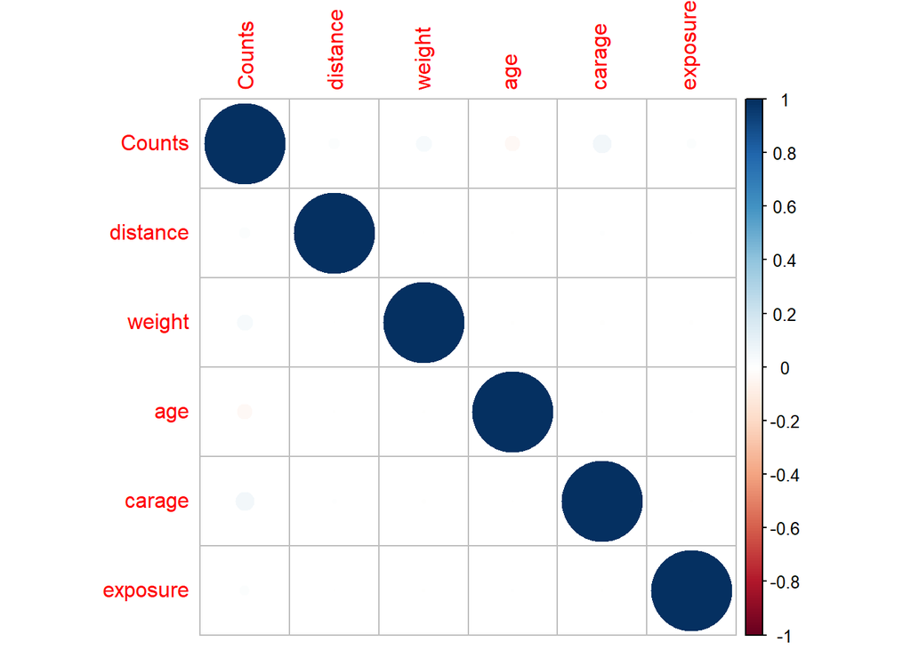

```r
corrplot(cor(data[-2]))
```

We plot the histograms all all the numeric variables (excluding sex). Our response variable Counts seems not to far from a Poisson distribution with a lot of $0$s.

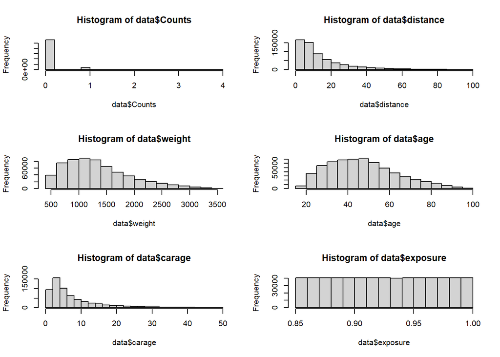

```r
par(mfrow=c(3,2))
hist(data$Counts)
hist(data$distance)
hist(data$weight)
hist(data$age)
hist(data$carage)
hist(data$exposure)
```

#### a. Estimating $\lambda(x)$ with a Generalized Linear Model

We fit a Poisson Generalized Linear Model for the estimation of $\lambda(x)$ considering linear, quadratic and mixed terms:

$$\begin{align*}
\log(\lambda) = & \ \beta_0 + \beta_1 \text{weight} + \beta_2
\text{distance} + \beta_3 \text{age} + \beta_4 \text{carage} + \beta_5
\text{sex} \\
& + \beta_6 \text{weight}^2 + \beta_7 \text{distance}^2 +
\beta_8 \text{age}^2 + \beta_9 \text{carage}^2 \\
& + \beta_{10} (\text{weight} \cdot \text{distance}) +
\beta_{11} (\text{weight} \cdot \text{age}) + \beta_{12} (\text{weight}
\cdot \text{carage}) \\
& + \beta_{13} (\text{distance} \cdot \text{age}) + \beta_{14}
(\text{distance} \cdot \text{carage}) + \beta_{15} (\text{age} \cdot
\text{carage}) \\
& + \log(\text{exposure})
\end{align*}$$

```r
model_glm<-glm(Counts~distance+weight+sex+carage+age +I(age^2)+I(distance^2)+
                I(weight^2)+I(carage^2)+I(age^2)+distance*weight+age*carage+
                distance*age+ age*weight+ distance*carage+carage*weight, data=data,
                family=poisson(), offset=log(exposure),weights = NULL)
summary(model_glm)
```

```
##
## Call:
## glm(formula = Counts ~ distance + weight + sex + carage + age +
##     I(age^2) + I(distance^2) + I(weight^2) + I(carage^2) + I(age^2) +
##     distance * weight + age * carage + distance * age + age *
##     weight + distance * carage + carage * weight, family = poisson(),
##     data = data, weights = NULL, offset = log(exposure))
##
## Coefficients:
##                   Estimate Std. Error z value Pr(>|z|)
## (Intercept)     -2.425e+00  5.935e-02 -40.858  < 2e-16 ***
## distance         4.036e-03  1.354e-03   2.981  0.00288 **
## weight           3.081e-04  4.038e-05   7.630 2.35e-14 ***
## sexmale         -6.838e-02  9.197e-03  -7.436 1.04e-13 ***
## carage           2.319e-02  2.534e-03   9.149  < 2e-16 ***
## age             -1.858e-02  1.664e-03 -11.166  < 2e-16 ***
## I(age^2)         1.136e-04  1.421e-05   7.990 1.35e-15 ***
## I(distance^2)   -6.297e-06  1.222e-05  -0.515  0.60624
## I(weight^2)     -2.101e-08  9.713e-09  -2.163  0.03055 *
## I(carage^2)     -7.258e-05  4.461e-05  -1.627  0.10374
## distance:weight  2.204e-07  4.605e-07   0.479  0.63220
## carage:age      -1.677e-05  3.221e-05  -0.521  0.60261
## distance:age    -9.971e-06  1.777e-05  -0.561  0.57470
## weight:age      -3.740e-07  4.519e-07  -0.828  0.40795
## distance:carage  4.499e-05  3.244e-05   1.387  0.16549
## weight:carage   -2.831e-07  8.362e-07  -0.339  0.73490
## ---
## Signif. codes:  0 '***' 0.001 '**' 0.01 '*' 0.05 '.' 0.1 ' ' 1
##
## (Dispersion parameter for poisson family taken to be 1)
##
##     Null deviance: 251528  on 609999  degrees of freedom
## Residual deviance: 248121  on 609984  degrees of freedom
## AIC: 342575
##
## Number of Fisher Scoring iterations: 6
```

```r
round(model_glm$coefficients, 6)
```

```
##     (Intercept)        distance          weight         sexmale          carage
##       -2.424788        0.004036        0.000308       -0.068385        0.023186
##             age        I(age^2)   I(distance^2)     I(weight^2)     I(carage^2)
##       -0.018580        0.000114       -0.000006        0.000000       -0.000073
## distance:weight      carage:age    distance:age      weight:age distance:carage
##        0.000000       -0.000017       -0.000010        0.000000        0.000045
##   weight:carage
##        0.000000
```

```r
summary(backward_model)
```

[output not shown]

We also performed a backwards selection with BIC criterion to penalize more the coefficients. Following this approach we decide to remove also $\text{weight}^2$, which was not bringing a big improvement even in deviance.

So we compute again our final GLM model and we plot our final coefficients.

$$\begin{align*}
\log(\lambda) = & \ \beta_0 + \beta_1 \text{weight} + \beta_2
\text{distance} + \beta_3 \text{age} + \beta_4 \text{carage} + \beta_5
\text{sex} \\
& \beta_6 \text{age}^2 + \log(\text{exposure})
\end{align*}$$

```r
model_glm<-glm(Counts~distance+weight+sex+carage+age +I(age^2), data=data,
               family=poisson(), offset=log(exposure),
               weights = NULL)
summary(model_glm)
```

```
##
## Call:
## glm(formula = Counts ~ distance + weight + sex + carage + age +
##     I(age^2), family = poisson(), data = data, weights = NULL,
##     offset = log(exposure))
##
## Coefficients:
##               Estimate Std. Error z value Pr(>|z|)
## (Intercept) -2.331e+00  3.762e-02 -61.971  < 2e-16 ***
## distance     3.941e-03  2.856e-04  13.798  < 2e-16 ***
## weight       2.224e-04  7.242e-06  30.708  < 2e-16 ***
## sexmale     -6.836e-02  9.197e-03  -7.433 1.06e-13 ***
## carage       2.029e-02  5.167e-04  39.262  < 2e-16 ***
## age         -1.945e-02  1.467e-03 -13.255  < 2e-16 ***
## I(age^2)     1.137e-04  1.421e-05   7.998 1.26e-15 ***
## ---
## Signif. codes:  0 '***' 0.001 '**' 0.01 '*' 0.05 '.' 0.1 ' ' 1
##
## (Dispersion parameter for poisson family taken to be 1)
##
##     Null deviance: 251528  on 609999  degrees of freedom
## Residual deviance: 248132  on 609993  degrees of freedom
## AIC: 342568
##
## Number of Fisher Scoring iterations: 6
```

```r
round(model_glm$coefficients, 6)
```

```
## (Intercept)    distance      weight     sexmale      carage         age
##   -2.331262    0.003941    0.000222   -0.068362    0.020286   -0.019445
##    I(age^2)
##    0.000114
```

We check the Pearson dispersion to check if our Poisson assumption on the response variable Counts and we confirm that our assumption is good because the coefficients is close to $1$.

```r
Pearson.dispersion <- (sum((data$Counts-fitted(model_glm))^2/fitted(model_glm)))/
                                                (n-length(model_glm$coefficients))
Pearson.dispersion
```

```
## [1] 1.000337
```

As a benchmark, we report the estimate $λ(x)$ for Weight = 1000, Distance = 10, Age = 27, CarAge = 5, Sex = male.

```r
newdata <- data.frame(distance = 1000, weight = 10, sex = "male", carage = 5,
                                                          age = 27, exposure = 1)
lambda_x_glm <- predict(model_glm, newdata, offset = log(newdata$exposure),
                                                                  type="response")
#λ=v*exp(linear_predictor)
print(lambda_x_glm)
```

```
##        1
## 3.328414
```

And we plot $λ(x)$ versus Age when other predictors are Weight = 1000, Distance = 10, Age = 27, CarAge = 5, Sex = male.

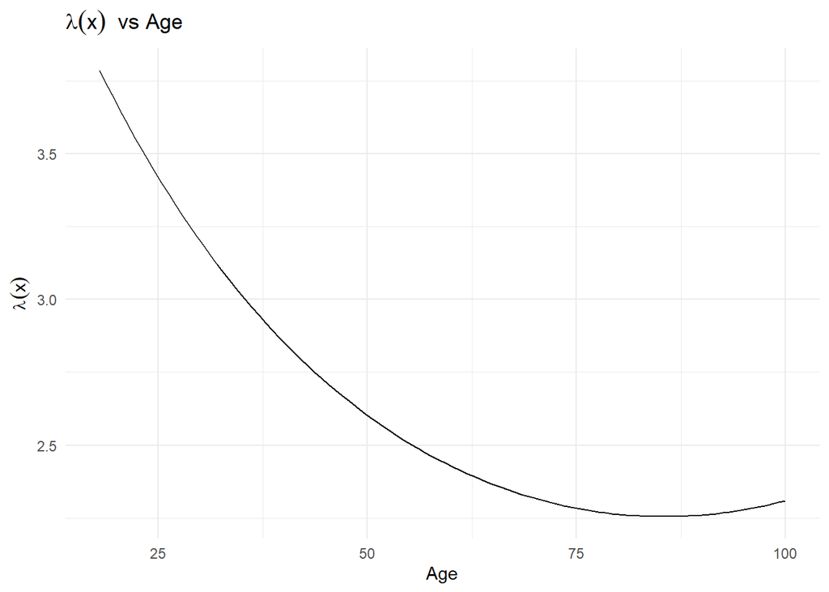

```r
age_values <- seq(min(data$age), max(data$age), length.out = 100)
plot_data_glm <- data.frame(distance = 1000, weight = 10, sex = "male", carage = 5,
                                                    age = age_values, exposure = 1)
lambda_x_plot_glm <- predict(model_glm, plot_data_glm, type = "response",
                                              offset = log(plot_data$exposure))
plot_data_glm$lambda_x <- lambda_x_plot_glm

ggplot(plot_data_glm, aes(x = age, y = lambda_x)) +
  geom_line(color = "Black") +
  labs(x = "Age", y = expression(lambda(x)),
       title = expression(lambda(x) ~ " vs Age")) +
  theme_minimal()
```

#### b. Estimate $\lambda(x)$ using Poisson regression tree

Now we want to estimate lambda using Poisson regression tree model.

```r
tree_mod <- rpart(cbind(exposure,Counts) ~ weight + distance + carage + age,
                            data = data,
                            method = "poisson",
                            parms = list(shrink=1),
                            control = rpart.control(xval=1,
                                      minbucket=8000,cp=0.0000001, maxdepth=8))

summary(tree_mod)
```

```
## Call:
## rpart(formula = cbind(exposure, Counts) ~ weight + distance +
##     carage + age, data = data, method = "poisson", parms = list(shrink = 1),
##     control = rpart.control(xval = 1, minbucket = 8000, cp = 1e-07,
##         maxdepth = 8))
##   n= 610000
##
##              CP nsplit rel error
## 1  3.999700e-03      0 1.0000000
## 2  2.199094e-03      1 0.9960003
## 3  1.240357e-03      2 0.9938012
## 4  8.329627e-04      3 0.9925608
## 5  4.716478e-04      4 0.9917279
## 6  4.294739e-04      5 0.9912562
## 7  2.760429e-04      6 0.9908268
## 8  2.670447e-04      7 0.9905507
## 9  2.420704e-04      8 0.9902837
## 10 2.064862e-04      9 0.9900416
## 11 2.053187e-04     10 0.9898351
## 12 2.014597e-04     11 0.9896298
## 13 1.960698e-04     12 0.9894283
## 14 1.546975e-04     13 0.9892323
## 15 1.280610e-04     14 0.9890776
## 16 1.248277e-04     15 0.9889495
## 17 1.182203e-04     16 0.9888247
## 18 1.002423e-04     17 0.9887065
## 19 8.426266e-05     18 0.9886062
## 20 7.226652e-05     19 0.9885220
## 21 6.956724e-05     20 0.9884497
## 22 5.745560e-05     21 0.9883801
## 23 5.542165e-05     22 0.9883227
## 24 5.495508e-05     23 0.9882673
## 25 4.855105e-05     24 0.9882123
## 26 4.726139e-05     25 0.9881637
## 27 4.726093e-05     26 0.9881165
## 28 4.721546e-05     27 0.9880692
## 29 4.417246e-05     28 0.9880220
## 30 3.886872e-05     29 0.9879778
## 31 3.622217e-05     30 0.9879390
## 32 2.720271e-05     31 0.9879027
```

[output cut: 484 more lines]

```
##
## Node number 289: 26948 observations
##   events=1766,  estimated rate=0.07085611 , mean deviance=0.363022
##
## Node number 292: 18394 observations
##   events=1235,  estimated rate=0.07256677 , mean deviance=0.3697992
##
## Node number 293: 8860 observations
##   events=674,  estimated rate=0.08218394 , mean deviance=0.3968355
##
## Node number 294: 27830 observations
##   events=2122,  estimated rate=0.08241774 , mean deviance=0.4002628
##
## Node number 295: 17081 observations
##   events=1425,  estimated rate=0.09016252 , mean deviance=0.4236217
```

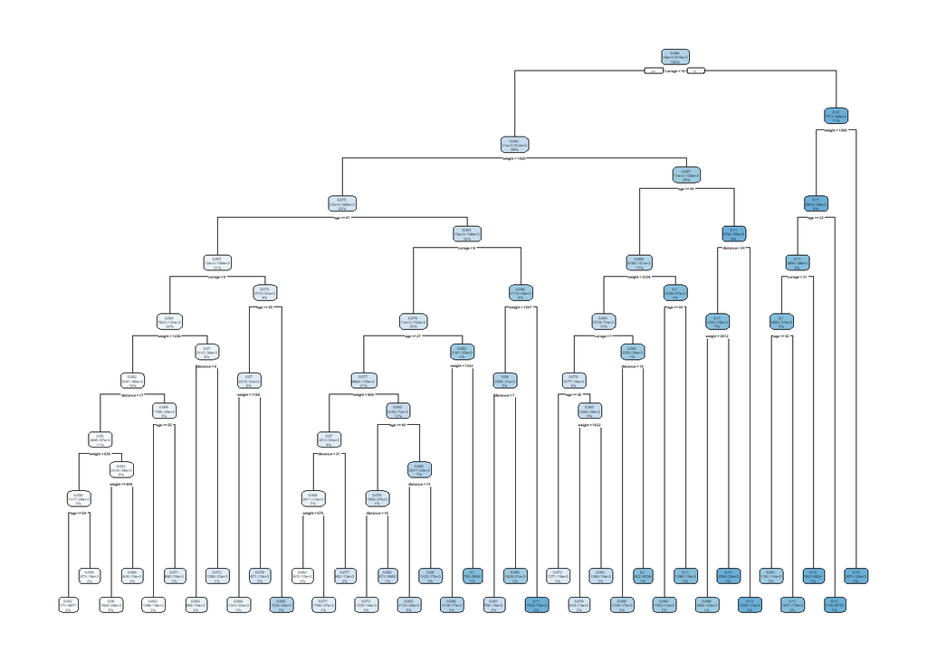

```r
rpart.plot(tree_mod)
```

Now we find the optimal value of “cp”, the complexity parameter, using a $10$-fold cross validation. We plot the relative error from cross validation versus the logarithm of the complexity parameter.

```r
tree_cv <- rpart(cbind(exposure,Counts)~weight+distance+carage+age,
                            data=data,
                            method="poisson",
                            parms=list(shrink=1),
                            control = rpart.control(xval=10,
                                         minbucket=8000,cp=0.0000001,maxdepth=8))
```

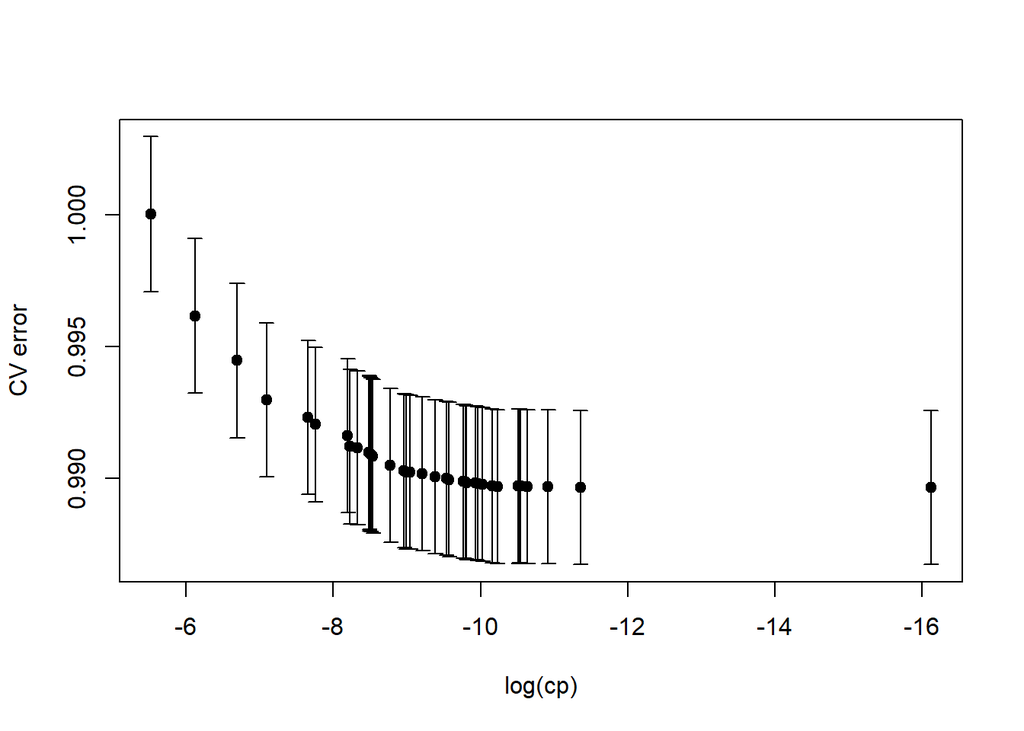

```r
plot(log(tree_cv$cp[,1]), tree_cv$cp[,4],
     ylim=range(c(tree_cv$cp[,4]-tree_cv$cp[,5], tree_cv$cp[,4]+tree_cv$cp[,5])),
     pch=19, xlab="log(cp)", ylab="CV error",
     main=" ", xlim=rev(range(log(tree_cv$cp[,1]))))

# draw arrows but with very special "arrowheads"
arrows(log(tree_cv$cp[,1]), tree_cv$cp[,4]-tree_cv$cp[,5], log(tree_cv$cp[,1]),
       tree_cv$cp[,4]+tree_cv$cp[,5], length=0.05, angle=90, code=3)
```

Now we found the optimal value of the complexity parameter using a function. This function first find the minimum “cp” and then according to the one-standard error rule, finds the first smallest tree with CV error just below the standard error limit.

```r
cp.select <- function(tree){
  min.x <- which.min(tree$cp[, 4])
  for(i in 1:nrow(tree$cp)){
    if(tree$cp[i, 4] < tree$cp[min.x, 4]
       + tree$cp[min.x, 5]){
      return(tree$cp[i, 1])
    }
  }
}
cp.optimal<-cp.select(tree_cv)
cp.optimal
```

```
## [1] 0.0004716478
```

Using the optimal complexity parameter, without approximation to not occur into errors we prun our tree obtaining our final model.

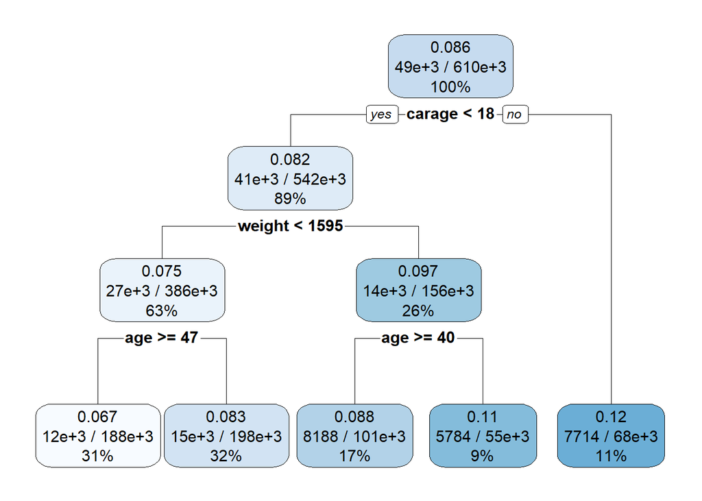

```r
tree_cv_pruned <- prune(tree_cv, cp=cp.optimal)
rpart.plot(tree_cv_pruned)
```

```r
tree_cv_pruned
```

```
## n= 610000
##
## node), split, n, deviance, yval
##       * denotes terminal node
##
##  1) root 610000 251528.50 0.08616833
##    2) carage< 17.5 542327 215832.90 0.08154382
##      4) weight< 1595.376 386095 146012.00 0.07541112
##        8) age>=46.5 188027  65870.07 0.06709640 *
##        9) age< 46.5 198068  79829.94 0.08330249 *
##      5) weight>=1595.376 156232  69267.76 0.09670309
##       10) age>=39.5 100813  42054.15 0.08782621 *
##       11) age< 39.5 55419  27004.10 0.11284620 *
##    3) carage>=17.5 67673  34689.53 0.12322000 *
```

As before, we use the model to predict $λ(x)$ for Weight = 1000, Distance = 10, Age = 27, CarAge = 5, Sex = male.

```r
log_lambda_x_tree <- predict(tree_cv_pruned, newdata)

lambda_x_tree <- newdata$exposure * exp(log_lambda_x_tree)
print(lambda_x_tree)
```

```
##        1
## 1.086871
```

And we plot $λ(x)$ versus Age when other predictors are Weight = 1000, Distance = 10, Age = 27, CarAge = 5, Sex = male. We obtained a step graph as expected from the calculation of the Poisson regression trees.

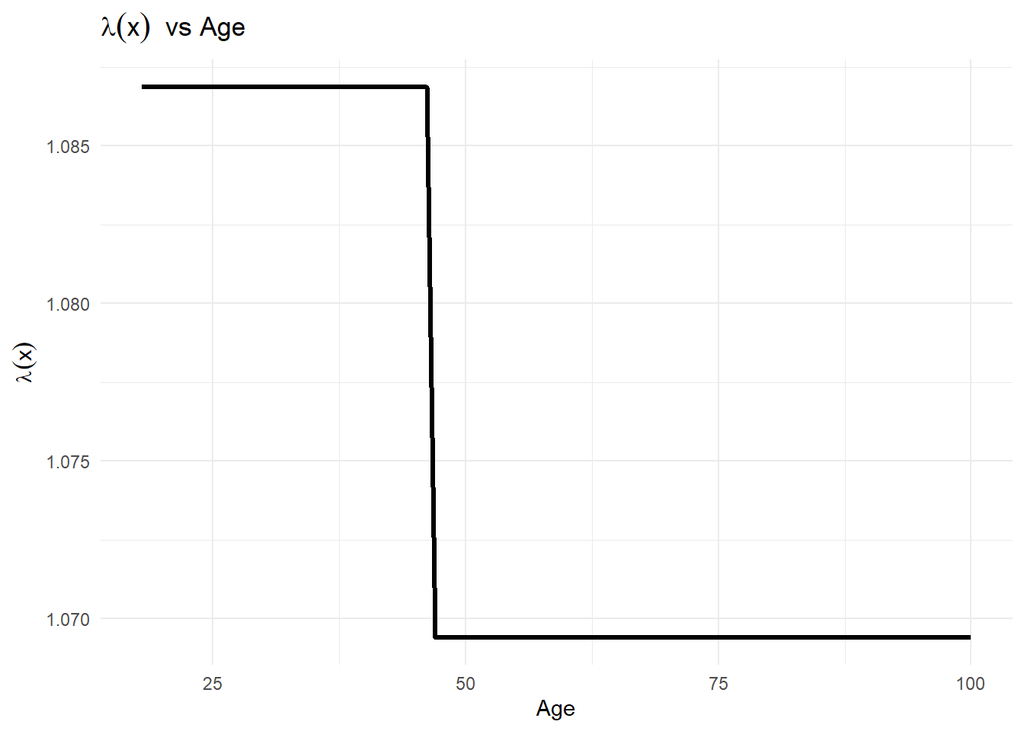

```r
plot_data_tree<- data.frame(distance = 1000, weight = 10, sex = "male", carage = 5,
                                                     age = age_values, exposure = 1)
lambda_x_plot_tree <- exp(predict(tree_cv_pruned, plot_data_tree))
plot_data_tree <- data.frame(age = age_values, lambda_x = lambda_x_plot_tree)
ggplot(plot_data_tree, aes(x = age, y = lambda_x)) +
  geom_line(color = "black", size = 1.2) +
  labs(x = "Age", y = expression(lambda(x)),
       title = expression(lambda(x) ~ " vs Age")) +
  theme_minimal()
```

#### c. Estimate $\lambda(x)$ using Poisson boosting tree method with no base model

Now we split the data in training and test set to tune the parameter when using using Poisson boosting tree method. We train a model on training set with $40$ number of trees, $0.5$ as shrinkage parameters and the tree depth as $2$.

```r
trainsampleindex <- sample(c(1:nrow(data)), 0.8 * nrow(data), replace = FALSE)
train <- data[trainsampleindex,]
test <- data[-trainsampleindex,]

boost_no_base <- gbm(Counts ~ offset(log(exposure)) + weight + distance + age +
                            carage + sex, data = train, distribution = "poisson",
                            n.trees = 40, shrinkage = 0.5, interaction.depth = 2)
```

We plot how the out of sample error develop with different number of trees (from $1$ to $40$). after we look for the minimum error and the corresponding optimal number of trees.

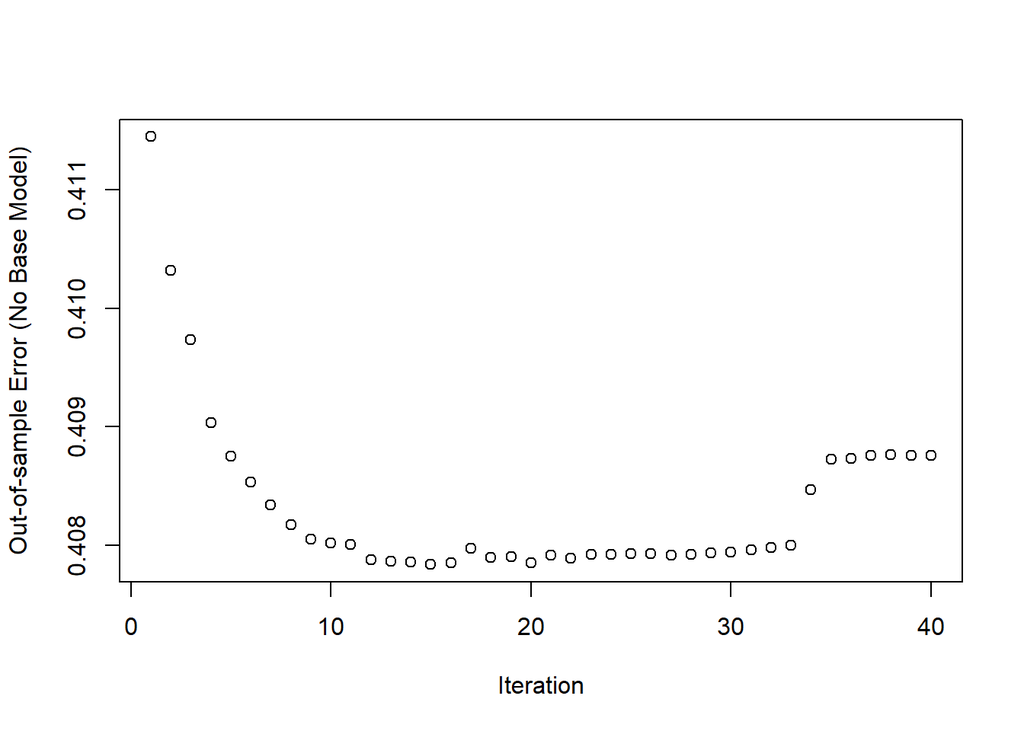

```r
out_sample_error_no_base <- vector()
K = 40
for(k in 1:K) {
  test$fit <- test$exposure * suppressWarnings(predict(boost_no_base,
                                 newdata = test, n.trees = k, type = "response"))
  out_sample_error_no_base[k] <- 2 * (sum(log((test$Counts / test$fit)^test$Counts))-
                                        sum(test$Counts) + sum(test$fit)) / nrow(test)
}
plot(seq(1:K), out_sample_error_no_base, xlab = "Iteration",
                                     ylab = "Out-of-sample Error (No Base Model)")
```

```r
which.min(out_sample_error_no_base)
```

```
## [1] 15
```

```r
out_sample_error_no_base[which.min(out_sample_error_no_base)]
```

```
## [1] 0.4078387
```

Now, after this quick previous trial, we want to tune more our model. We use a grid search with “shrinkage” $= [0.3, 0.5, 0.7]$ and “interaction.depth” $=[2,4]$. We compute the validation error $5$ times for each combination of parameters and we save the optimal number of trees. Looking at the average out of sample error we find the optimal parameters and the corresponding average numbers of trees.

```r
param_combinations <- expand.grid(
  shrinkage = c(0.5, 0.7, 0.3),
  interaction.depth = c(2, 4)
)

# Initialize lists to store results
results <- list()

# Number of repetitions for each parameter combination
n_repeats <- 5

# Loop through each parameter combination
for (i in 1:nrow(param_combinations)) {
  shrinkage <- param_combinations$shrinkage[i]
  interaction.depth <- param_combinations$interaction.depth[i]

  errors <- numeric(n_repeats)
  n_trees_optimal <- numeric(n_repeats)

  # Repeat the model fitting and error calculation n_repeats times
  for (j in 1:n_repeats) {
    # Fit the gbm model
    boost_no_base<-gbm(Counts ~ offset(log(exposure))+weight+distance+age+carage+sex,
                         data = train,
                         distribution = "poisson",
                         n.trees = 40,
                         shrinkage = shrinkage,
                         interaction.depth = interaction.depth)

    # Out-of-sample error analysis
    out_sample_error_no_base <- numeric(40)
    K <- 40
    for (k in 1:K) {
      test$fit <- test$exposure * suppressWarnings(predict(boost_no_base,
                                  newdata = test, n.trees = k, type = "response"))
      out_sample_error_no_base[k] <- 2 * (sum(log((test$Counts / test$fit)^test$Counts))-
                                          sum(test$Counts) + sum(test$fit)) / nrow(test)
    }
  # Store the error and optimal number of trees for this repeat
  errors[j] <- min(out_sample_error_no_base)
  n_trees_optimal[j] <- which.min(out_sample_error_no_base)
  }

  # Calculate the mean error and mean optimal number of trees
  mean_error <- mean(errors)
  mean_n_trees_optimal <- mean(n_trees_optimal)

  # Store the results
  results[[paste("shrinkage", shrinkage, "depth", interaction.depth)]] <- list(
    mean_error = mean_error,
    mean_n_trees_optimal = mean_n_trees_optimal)
}
```

```r
results
```

```
## $`shrinkage 0.5 depth 2`
## $`shrinkage 0.5 depth 2`$mean_error
## [1] 0.4078543
##
## $`shrinkage 0.5 depth 2`$mean_n_trees_optimal
## [1] 18.2
##
##
## $`shrinkage 0.7 depth 2`
## $`shrinkage 0.7 depth 2`$mean_error
## [1] 0.4079745
##
## $`shrinkage 0.7 depth 2`$mean_n_trees_optimal
## [1] 17
##
##
## $`shrinkage 0.3 depth 2`
## $`shrinkage 0.3 depth 2`$mean_error
## [1] 0.4076747
##
## $`shrinkage 0.3 depth 2`$mean_n_trees_optimal
## [1] 33.6
##
##
## $`shrinkage 0.5 depth 4`
## $`shrinkage 0.5 depth 4`$mean_error
## [1] 0.4079636
##
## $`shrinkage 0.5 depth 4`$mean_n_trees_optimal
## [1] 13.2
##
##
## $`shrinkage 0.7 depth 4`
## $`shrinkage 0.7 depth 4`$mean_error
## [1] 0.4082863
##
## $`shrinkage 0.7 depth 4`$mean_n_trees_optimal
## [1] 8.4
##
##
## $`shrinkage 0.3 depth 4`
## $`shrinkage 0.3 depth 4`$mean_error
## [1] 0.4077969
##
## $`shrinkage 0.3 depth 4`$mean_n_trees_optimal
## [1] 21.8
```

The minimum average error we found is $0.4076747$ with an average number of trees of $33.6$ Now we compute the boosting tree model with no base with the optimal parameters we found : “shrinkage” $=0.3$ and “interaction.depth” $=2$. We compute first with $50$ trees to check again the optimal number of trees.

```r
boost_no_base_tuned<- gbm(Counts~offset(log(exposure))+weight+distance+age+carage+sex,
                          data = train,
                          distribution = "poisson",
                          n.trees = 50,
                          shrinkage = 0.3,
                          interaction.depth = 2)
```

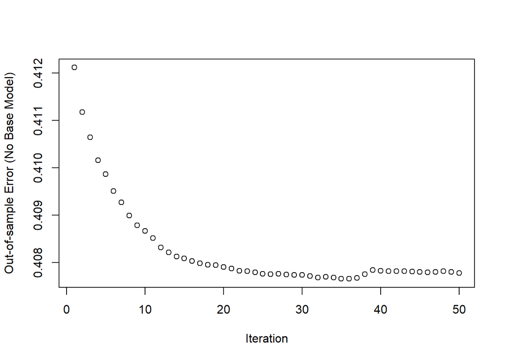

```r
out_sample_error_no_base_tuned <- vector()
K = 50
for(k in 1:K) {
  test$fit <- test$exposure * suppressWarnings(predict(boost_no_base_tuned, newdata=test,
                                                      n.trees = k, type = "response"))
  out_sample_error_no_base_tuned[k] <- 2 * (sum(log((test$Counts / test$fit)^test$Counts))-
                                              sum(test$Counts) + sum(test$fit)) / nrow(test)
}
plot(seq(1:K), out_sample_error_no_base_tuned, xlab = "Iteration",
                                    ylab = "Out-of-sample Error (No Base Model)")
```

```r
which.min(out_sample_error_no_base_tuned)
```

```
## [1] 36
```

```r
out_sample_error_no_base_tuned[which.min(out_sample_error_no_base_tuned)]
```

```
## [1] 0.4076537
```

```r
boost_no_base_tuned<- gbm(Counts ~ offset(log(exposure))+weight+distance+age+carage+sex,
                          data = data,
                          distribution = "poisson",
                          n.trees = 37,
                          shrinkage = 0.3,
                          interaction.depth = 2)
```

```r
#newdata <- data.frame(distance = 1000, weight = 10, sex = "male", carage = 5,
#                                                         age = 27, exposure = 1)
lambda_x_boost <- predict(boost_no_base_tuned, newdata, n.trees = 37,
                                                               type = "response")

lambda_x_boost
```

```
## [1] 0.08861499
```

We plot $λ(x)$ versus Age when other predictors are Weight $= 1000$, Distance $= 10$, Age $= 27$, CarAge $= 5$, Sex = male. We obtained a step graph with more steps than before as expected from the calculation of the Poisson regression trees with boosting.

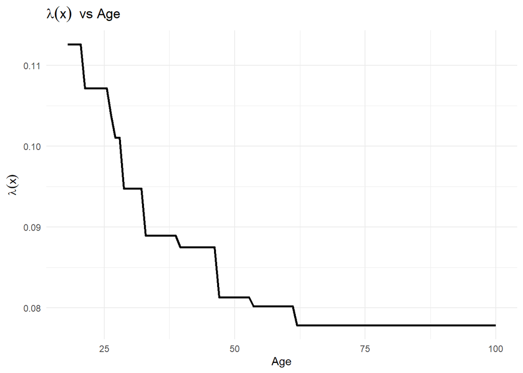

```r
#age_values <- seq(min(data$age), max(data$age), length.out = 100)
plot_data_boost <- data.frame(distance = 1000, weight = 10, sex = "male",
                                     carage = 5, age = age_values, exposure = 1)
plot_data_boost$lambda_x <- predict(boost_no_base_tuned, newdata = plot_data_boost,
                                                    n.trees = 30, type = "response")
ggplot(plot_data_boost, aes(x = age, y = lambda_x)) +
  geom_line(color = "black", size = 1) +
  labs(x = "Age", y = expression(lambda(x)), title = expression(lambda(x) ~" vs Age"))+
  theme_minimal()
```

#### d Estimate $\lambda(x)$ Poisson boosting tree method with base model

As at the point c., we want to estimate $\lambda(x)$, but this time with Poisson boosting tree model with base model (GLM model fitted in section a.). We start directly with our grid search for the optimal parameters “shrinkage” $= [0.3, 0.5, 0.7]$ and “interaction.depth” $=[2,4]$. with each combination of parameters we compute 5 times the model on train data and validation error on the test data to have a more robust result when applying boosting.

```r
test<-test[,-8]

train$base_pred <- predict(model_glm, newdata = train, type = "response")
test$base_pred <- predict(model_glm, newdata = test, type = "response")
```

```r
library(gbm)

param_combinations <- expand.grid(
  shrinkage = c(0.5, 0.7, 0.3),
  interaction.depth = c(2, 4)
)


results_with_base <- list()

#Number of repetitions
n_repeats <- 5

for (i in 1:nrow(param_combinations)) {
  shrinkage <- param_combinations$shrinkage[i]
  interaction.depth <- param_combinations$interaction.depth[i]

  errors_with_base <- numeric(n_repeats)
  n_trees_optimal_with_base <- numeric(n_repeats)


  for (j in 1:n_repeats) {
    boost_with_base <- gbm(Counts ~ offset(base_pred) + weight + distance + age + carage + sex,
                           data = train,
                           distribution = "poisson",
                           n.trees = 40,
                           shrinkage = shrinkage,
                           interaction.depth = interaction.depth)

    # Out-of-sample error
    out_sample_error_with_base <- numeric(40)
    K <- 40
    for (k in 1:K) {
      test$fit <- test$exposure*suppressWarnings(predict(boost_with_base,
                                  newdata = test, n.trees = k, type = "response"))
      out_sample_error_with_base[k]<-2*(sum(log((test$Counts/test$fit)^test$Counts))-
                                    sum(test$Counts) + sum(test$fit)) / nrow(test)
    }

    # Store the error and optimal number of trees
    errors_with_base[j] <- min(out_sample_error_with_base)
    n_trees_optimal_with_base[j] <- which.min(out_sample_error_with_base)
  }

  # Calculate the mean error and mean
  mean_error_with_base <- mean(errors_with_base)
  mean_n_trees_optimal_with_base <- mean(n_trees_optimal_with_base)

  results_with_base[[paste("shrinkage", shrinkage, "depth", interaction.depth)]]<-list(
    mean_error = mean_error_with_base,
    mean_n_trees_optimal = mean_n_trees_optimal_with_base
  )
}
```

```r
results_with_base
```

```
## $`shrinkage 0.5 depth 2`
## $`shrinkage 0.5 depth 2`$mean_error
## [1] 0.4100123
##
## $`shrinkage 0.5 depth 2`$mean_n_trees_optimal
## [1] 25.6
##
##
## $`shrinkage 0.7 depth 2`
## $`shrinkage 0.7 depth 2`$mean_error
## [1] 0.4100076
##
## $`shrinkage 0.7 depth 2`$mean_n_trees_optimal
## [1] 19.6
##
##
## $`shrinkage 0.3 depth 2`
## $`shrinkage 0.3 depth 2`$mean_error
## [1] 0.4099674
##
## $`shrinkage 0.3 depth 2`$mean_n_trees_optimal
## [1] 30.8
##
##
## $`shrinkage 0.5 depth 4`
## $`shrinkage 0.5 depth 4`$mean_error
## [1] 0.4101808
##
## $`shrinkage 0.5 depth 4`$mean_n_trees_optimal
## [1] 10.8
##
##
## $`shrinkage 0.7 depth 4`
## $`shrinkage 0.7 depth 4`$mean_error
## [1] 0.410414
##
## $`shrinkage 0.7 depth 4`$mean_n_trees_optimal
## [1] 9.6
##
##
## $`shrinkage 0.3 depth 4`
## $`shrinkage 0.3 depth 4`$mean_error
## [1] 0.4099607
##
## $`shrinkage 0.3 depth 4`$mean_n_trees_optimal
## [1] 21
```

```r
boost_base_tuned<- gbm(Counts~offset(base_pred) +weight+distance+age+carage+sex,
                          data = train,
                          distribution = "poisson",
                          n.trees = 50,
                          shrinkage = 0.3,
                          interaction.depth = 2)
```

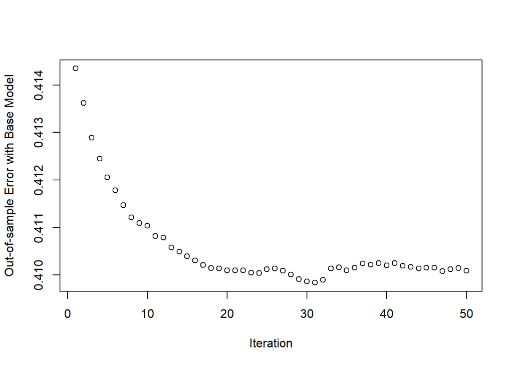

```r
out_sample_error_base_tuned <- vector()
K = 50
for(k in 1:K) {
  test$fit <- test$exposure * suppressWarnings(predict(boost_base_tuned,
                                newdata = test, n.trees = k, type = "response"))
  out_sample_error_base_tuned[k]<- 2*(sum(log((test$Counts / test$fit)^test$Counts))-
                                       sum(test$Counts) + sum(test$fit)) / nrow(test)
}
plot(seq(1:K), out_sample_error_base_tuned, xlab = "Iteration",
                                      ylab = "Out-of-sample Error with Base Model")
```

```r
which.min(out_sample_error_base_tuned)
```

```
## [1] 31
```

```r
out_sample_error_base_tuned[which.min(out_sample_error_base_tuned)]
```

```
## [1] 0.409842
```

```r
#newdata <- data.frame(distance = 1000, weight = 10, sex = "male", carage = 5,
#                                                        age = 27, exposure = 1)
lambda_x_boost_with_base<- predict(boost_base_tuned, newdata, n.trees = 23,
                                        type = "response")
lambda_x_boost_with_base
```

```
## [1] 0.07574377
```

We plot $λ(x)$ versus Age when other predictors are Weight $= 1000$, Distance $= 10$, Age $= 27$, CarAge $= 5$, Sex = male. We obtained a step graph with more steps than before as expected from the calculation of the Poisson regression trees with boosting using as base model the GLM computed previously.

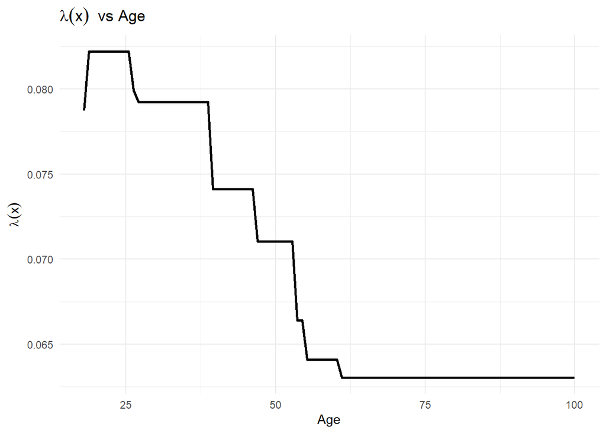

```r
#age_values <- seq(min(data$age), max(data$age), length.out = 100)
plot_data_boost_with_base <- data.frame(distance = 1000, weight = 10, sex = "male",
                                         carage = 5, age = age_values, exposure = 1)
plot_data_boost_with_base$lambda_x <- predict(boost_base_tuned,
                newdata = plot_data_boost_with_base, n.trees = 31, type = "response")
ggplot(plot_data_boost_with_base, aes(x = age, y = lambda_x)) +
  geom_line(color = "black", size = 1) +
  labs(x = "Age", y = expression(lambda(x)), title = expression(lambda(x) ~
                                                                   " vs Age")) +
  theme_minimal()
```

#### e. Estimate $\lambda(x)$ modelled by a one-layer Neural Network

```r
library(reticulate)
#py_discover_config()

use_condaenv("r-reticulate", conda = "C:/ProgramData/anaconda3/condabin/conda.bat")

py_discover_config()
```

```
## python:         C:/Users/Admin/.conda/envs/r-reticulate/python.exe
## libpython:      C:/Users/Admin/.conda/envs/r-reticulate/python38.dll
## pythonhome:     C:/Users/Admin/.conda/envs/r-reticulate
## version:        3.8.19 (default, Mar 20 2024, 19:55:45) [MSC v.1916 64 bit (AMD64)]
## Architecture:   64bit
## numpy:          C:/Users/Admin/.conda/envs/r-reticulate/Lib/site-packages/numpy
## numpy_version:  1.24.4
## tensorflow:     C:\Users\Admin\CONDA~1\envs\R-RETI~1\lib\site-packages\tensorflow\__init__.p
##
## NOTE: Python version was forced by use_python() function
```

```r
library(tensorflow)
library(keras)
# Install specific version of TensorFlow if needed
tensorflow::tf_config()
```

```
## TensorFlow v2.11.1 (C:\Users\Admin\CONDA~1\envs\R-RETI~1\lib\site-packages\tensorflow\__init__.p)
## Python v3.8 (C:/Users/Admin/.conda/envs/r-reticulate/python.exe)
```

```r
keras:::keras_version()
```

```
## [1] '2.11.0'
```

Now we estimate $\lambda(x)$ modelled by a one-layer Neural Network model with 10 neurons using tensorflow. The exposure is considered as a given factor. We use only $2$ integer covariates Age and Distance. We make our response variable as numeric, we save the 2 variables, that we are considering in a matrix and we normalize them.

```r
Y_train <- as.matrix(train$Counts)
Y_test <- as.matrix(test$Counts)

Y_train <- as.numeric(Y_train)
Y_test <- as.numeric(Y_test)

str(Y_train)
```

```
##  num [1:488000] 0 0 0 0 0 0 0 0 0 0 ...
```

```r
str(Y_test)
```

```
##  num [1:122000] 0 0 0 0 0 0 0 0 0 0 ...
```

```r
#Max-Min Normalization
normalize <- function(x,xmin,xmax) {
  return (2*((x - xmin) / (xmax - xmin))-1)
}

agemin<-min(data$age)
agemax<-max(data$age)
dmin<-min(data$distance)
dmax<-max(data$distance)

feature.train<-cbind(normalize(train$age,agemin,agemax),normalize(train$distance,dmin,dmax))
X.train <- list(as.matrix(feature.train), as.matrix((train$exposure)))

feature.test<-cbind(normalize(test$age,agemin,agemax),normalize(test$distance,dmin,dmax))
X.test <- list(as.matrix(feature.test), as.matrix((test$exposure)))
```

Here we set our number of neurons (10) and layers (1) and we define our model architecture. We also define our poisson loss function.

```r
q0<-2 #number of covariates
q1<-10 #number of neurons
lambda0<-sum(train$Counts)/sum(train$exposure)

Design<-layer_input(shape = c(q0), dtype = 'float32', name = 'Design')
Vol<-layer_input(shape = c(1), dtype = 'float32', name = 'LogVol')

Network = Design %>%
  layer_dense (units=q1 , activation ='tanh', name ='Layer1') %>%
  layer_dense (units=1, activation ='exponential', name ='Network',
               weights = list(array(0, dim=c(q1 ,1)) , array(log(lambda0), dim=c(1))))

Response = list(Network,Vol) %>% layer_multiply

#the package drops some terms in loss function loss = 'poisson' that do not depend on y_pred. Thus training and validation error curves are shifted on the plot. Thus we write custom loss function
Poisson_loss<-function(y_true,y_pred){
  2*k_mean(y_pred - y_true*k_log(y_pred)-y_true+y_true*k_log(k_maximum(y_true,1)))
}

model <- keras_model(inputs = list(Design,Vol), outputs = c(Response))

model %>% compile(optimizer=optimizer_nadam(), loss=Poisson_loss) #loss = 'poisson')

summary(model)
```

```
## Model: "model"
## ________________________________________________________________________________
##  Layer (type)             Output Shape      Param #  Connected to
## ================================================================================
##  Design (InputLayer)      [(None, 2)]       0        []
##  Layer1 (Dense)           (None, 10)        30       ['Design[0][0]']
##  Network (Dense)          (None, 1)         11       ['Layer1[0][0]']
##  LogVol (InputLayer)      [(None, 1)]       0        []
##  multiply (Multiply)      (None, 1)         0        ['Network[0][0]',
##                                                       'LogVol[0][0]']
## ================================================================================
## Total params: 41
## Trainable params: 41
## Non-trainable params: 0
## ________________________________________________________________________________
```

```r
history <- model %>% fit(X.train, Y_train,
                         epochs=70, batch_size = nrow(X.train),view_metrics = TRUE,
                         #validation_split = 0.2,
                         validation_data = list(X.test, Y_test),
                         verbose =0)
```

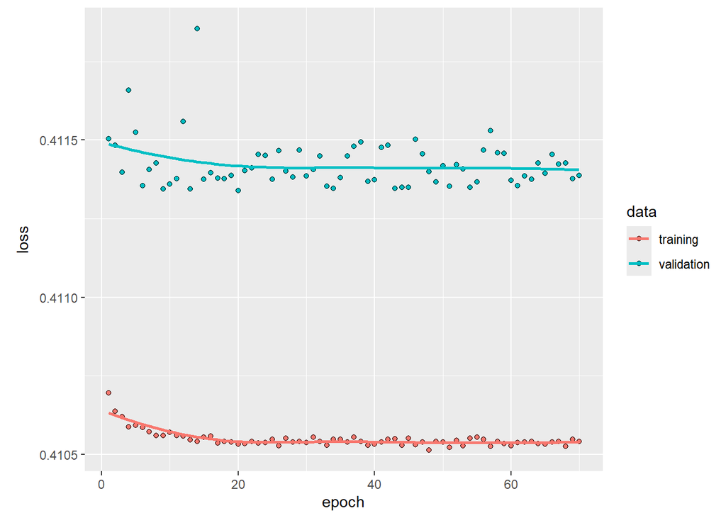

```r
plot(history)
```

Now we use the model to estimate of $(x) $for Weight = 1000 and Age = 27 obtaining $ 0.08607315 $.

```r
#new data point
new_data_NN <- data.frame(distance = 10, age = 27)

normalized_distance <- normalize(new_data_NN$distance, min(data$distance), max(data$distance))
normalized_age <- normalize(new_data_NN$age, min(data$age), max(data$age))

x_single <- list(as.matrix(cbind(normalized_age, normalized_distance)), as.matrix(1))

lambda_NN <- model %>% predict(x_single)
```

```
## 1/1 - 0s - 151ms/epoch - 151ms/step
```

```r
lambda_NN
```

```
##            [,1]
## [1,] 0.08607315
```

We plot $λ(x)$ versus Age when Weight = 1000.

```r
age_values <- seq(min(data$age), max(data$age), length.out = 100)
mean_distance <- 10
distance_value <- normalize(mean_distance, min(data$distance), max(data$distance))


xplot <- list(as.matrix(cbind(normalize(age_values, min(data$age), max(data$age)),
    rep(distance_value, length(age_values)))), as.matrix(rep(1, length(age_values))))
NN.fit <- model %>% predict(xplot)
```

```
## 4/4 - 0s - 84ms/epoch - 21ms/step
```

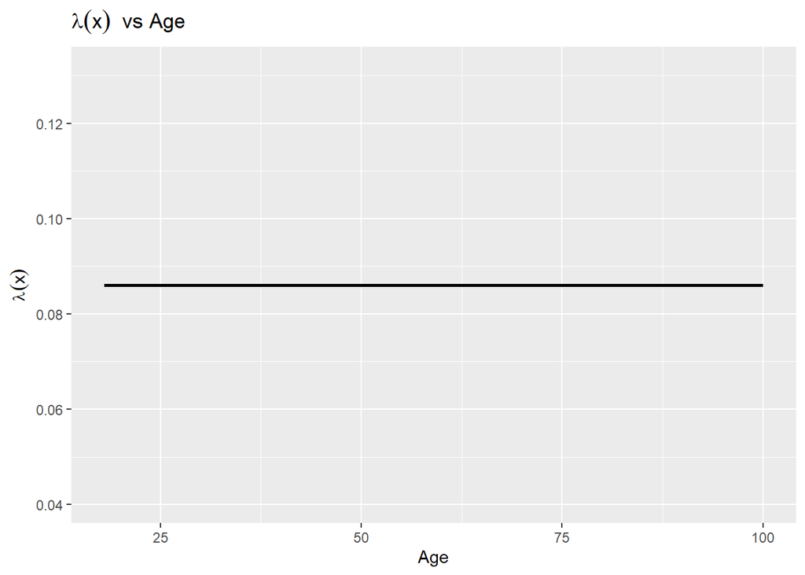

```r
plot_data <- data.frame(age = age_values, intensity = NN.fit)

ggplot(plot_data, aes(x = age, y = intensity)) +
  geom_line(size=1) +
  labs(x = "Age", y = expression(lambda(x)), title = expression(lambda(x) ~ " vs Age"))
```

#### f. Compare the models fitted in items a), b), c), d) and e)

We compare here the models fitted in items a), b), c), d) and e) using 10-fold cross validation error to select the best model.

```r
folds <- createFolds(data$Counts, k = 10, list = TRUE, returnTrain = TRUE)
poisson_deviance <- function(observed, predicted) {
  2 * (sum(log((observed/predicted)^observed))-sum(observed)+sum(predicted))/length(observed)
}

cross_validation_error <- function(data, folds) {
  errors <- data.frame(
    Model_a = numeric(length(folds)),
    Model_b = numeric(length(folds)),
    Model_c = numeric(length(folds)),
    Model_d = numeric(length(folds)))#,
    #Model_e = numeric(length(folds))
  #)

  for (i in seq_along(folds)) {
    train_indices <- folds[[i]]
    test_indices <- setdiff(seq_len(nrow(data)), train_indices)
    train_data <- data[train_indices, ]
    test_data <- data[test_indices, ]

    # Model a: Poisson regression with log link
    model_a <- glm(Counts ~ offset(log(exposure)) + weight + distance + carage +
                     age + sex+ I(age^2),
                   data = train_data, family = poisson(link = "log"))
    predicted_a <- predict(model_a, newdata = test_data, type = "response")
    errors$Model_a[i] <- poisson_deviance(test_data$Counts, predicted_a)

    # Model b: Poisson regression tree
    model_b <- rpart(cbind(exposure,Counts)~weight+distance+carage+age,
                     data=train_data,
                     method="poisson",
                     parms=list(shrink=1),
                     control = rpart.control(xval=10,
                                        minbucket=8000,cp=cp.optimal,maxdepth=8))
    predicted_b <- predict(model_b, newdata = test_data)
    errors$Model_b[i] <- poisson_deviance(test_data$Counts, predicted_b)

    # Model c: Poisson boosting tree with no base model
    model_c <- gbm(Counts ~ offset(log(exposure))+weight+distance+age+carage+sex,
                   data = train_data,
                   distribution = "poisson",
                   n.trees = 37,
                   shrinkage = 0.3,
                   interaction.depth = 2)
    predicted_c<-exp(predict(model_c, newdata = test_data, type = "link", n.tree=37)+
                                                      log(test_data$exposure))
    errors$Model_c[i]<-poisson_deviance(test_data$Counts, predicted_c)

    # Model d: Poisson boosting tree with the base model from a)
    train_data$base_pred <- predict(model_a, newdata = train_data, type = "link")
    test_data$base_pred <- predict(model_a, newdata = test_data, type = "link")
    model_d <- gbm(Counts ~ offset(base_pred)+weight+distance+age+carage+sex,
                                      data = train_data,
                                      distribution = "poisson",
                                      n.trees = 23,
                                      shrinkage = 0.3,
                                      interaction.depth = 2)
    predicted_d<-exp(predict(model_d, newdata = test_data, type = "link", n.tree=23)+
                                                           test_data$base_pred)
    errors$Model_d[i]<-poisson_deviance(test_data$Counts, predicted_d)

    ########################################
    #####NEURAL NETWORK
    ########################################
    # Prepare inputs for neural network training and prediction
    Y_train <- as.matrix(train_data$Counts)
    Y_test <- as.matrix(test_data$Counts)
    Y_train <- as.numeric(Y_train)
    Y_test <- as.numeric(Y_test)

    agemin <- min(data$age)
    agemax <- max(data$age)
    dmin <- min(data$distance)
    dmax <- max(data$distance)

    feature_train <- cbind(normalize(train_data$age, agemin, agemax),
                                normalize(train_data$distance, dmin, dmax))
    X_train <- list(as.matrix(feature_train), as.matrix(train_data$exposure))

    feature_test <- cbind(normalize(test_data$age, agemin, agemax),
                              normalize(test_data$distance, dmin, dmax))
    X_test <- list(as.matrix(feature_test), as.matrix(test_data$exposure))

    q0 <- 2  # number of covariates
    q1 <- 10  # number of neurons
    lambda0 <- sum(train_data$Counts) / sum(train_data$exposure)

    Design <- layer_input(shape = c(q0), dtype = 'float32', name = 'Design')
    Vol <- layer_input(shape = c(1), dtype = 'float32', name = 'LogVol')

    Network <- Design %>%
      layer_dense(units = q1, activation = 'tanh', name = 'Layer1') %>%
      layer_dense(units = 1, activation = 'exponential', name = 'Network',
                  weights = list(array(0, dim = c(q1, 1)), array(log(lambda0), dim = c(1))))

    Response <- list(Network, Vol) %>% layer_multiply

    # Custom Poisson loss function
    Poisson_loss <- function(y_true, y_pred) {
      2 * k_mean(y_pred - y_true * k_log(y_pred) - y_true + y_true * k_log(k_maximum(y_true, 1)))
    }

    model_nn <- keras_model(inputs = list(Design, Vol), outputs = c(Response))
    model_nn %>% compile(optimizer = optimizer_nadam(), loss = Poisson_loss)

    # Train the neural network model
    history <- model_nn %>% fit(X_train, Y_train,
                                epochs = 20, batch_size = nrow(X_train), view_metrics = TRUE,
                                validation_data = list(X_test, Y_test), verbose = 0)

    # Predict using the trained neural network model
    predicted_e <- model_nn %>% predict(X_test)
    #predicted_e <- exp(predicted_e)

    errors$Model_nn[i] <- poisson_deviance(test_data$Counts, predicted_e)

  }
  colMeans(errors)
}

errors_compared<-cross_validation_error(data=data, folds=folds)
```

```r
errors_compared
```

```
##   Model_a   Model_b   Model_c   Model_d  Model_nn
## 0.4067965 0.4097227 0.4071204 0.4070122 0.4107265
```

#### g. Poisson Generalized Linear Model with variable “High”

We continue the analysis by introducing a categorical variable, High, into the dataset. High is defined as “Yes” if the claims count of a policy $N \geq 2$, and “No” otherwise. Initially, we applied a logistic regression model using all available predictors, resulting in a residual deviance of $25648$.

```r
# Adding the High variable to the dataset
data$high <- ifelse(data$Counts>= 2, "Yes", "No")
data$High <- factor(data$high, levels = c("No", "Yes"))

table(data$high)
```

```
##
##     No    Yes
## 608060   1940
```

```r
# Fit the logistic regression model
logistic_model <- glm(High ~ weight+distance+age+carage+sex+I(distance^2)+
                   I(weight^2)+I(carage^2)+I(age^2)+distance*weight+age*carage+
                   distance*age+ age*weight+ distance*carage+carage*weight,
                    data=data, family=binomial)
summary(logistic_model)
```

```
##
## Call:
## glm(formula = High ~ weight + distance + age + carage + sex +
##     I(distance^2) + I(weight^2) + I(carage^2) + I(age^2) + distance *
##     weight + age * carage + distance * age + age * weight + distance *
##     carage + carage * weight, family = binomial, data = data)
##
## Coefficients:
##                   Estimate Std. Error z value Pr(>|z|)
## (Intercept)     -5.375e+00  2.881e-01 -18.654  < 2e-16 ***
## weight           4.975e-04  1.949e-04   2.553 0.010694 *
## distance         1.255e-03  6.262e-03   0.200 0.841153
## age             -4.753e-02  8.122e-03  -5.852 4.86e-09 ***
## carage           4.103e-02  1.134e-02   3.618 0.000297 ***
## sexmale         -1.733e-01  4.580e-02  -3.784 0.000155 ***
## I(distance^2)    9.310e-05  5.556e-05   1.676 0.093792 .
## I(weight^2)     -2.950e-08  4.663e-08  -0.633 0.526992
## I(carage^2)     -1.476e-04  1.987e-04  -0.743 0.457535
## I(age^2)         2.941e-04  7.059e-05   4.167 3.09e-05 ***
## weight:distance -1.106e-06  2.066e-06  -0.536 0.592215
## age:carage       8.189e-05  1.418e-04   0.577 0.563744
## distance:age     2.767e-05  8.156e-05   0.339 0.734414
## weight:age       1.848e-06  2.152e-06   0.858 0.390667
## distance:carage  5.142e-05  1.337e-04   0.384 0.700626
## weight:carage   -1.674e-06  3.577e-06  -0.468 0.639741
## ---
## Signif. codes:  0 '***' 0.001 '**' 0.01 '*' 0.05 '.' 0.1 ' ' 1
##
## (Dispersion parameter for binomial family taken to be 1)
##
##     Null deviance: 26187  on 609999  degrees of freedom
## Residual deviance: 25648  on 609984  degrees of freedom
## AIC: 25680
##
## Number of Fisher Scoring iterations: 9
```

After we selected the model by including only the significant predictors Weight, Age, CarAge, Sex, and $Age^2$ obtained a residual deviance of $25682$.

```r
# Fit the logistic regression model
logistic_model <- glm(High~weight+age+carage+sex+I(age^2), data = data, family=binomial)
summary(logistic_model)
```

```
##
## Call:
## glm(formula = High ~ weight + age + carage + sex + I(age^2),
##     family = binomial, data = data)
##
## Coefficients:
##               Estimate Std. Error z value Pr(>|z|)
## (Intercept) -5.343e+00  1.805e-01 -29.599  < 2e-16 ***
## weight       4.406e-04  3.471e-05  12.694  < 2e-16 ***
## age         -4.337e-02  7.195e-03  -6.028 1.66e-09 ***
## carage       3.768e-02  2.289e-03  16.462  < 2e-16 ***
## sexmale     -1.731e-01  4.580e-02  -3.779 0.000158 ***
## I(age^2)     2.944e-04  7.054e-05   4.173 3.00e-05 ***
## ---
## Signif. codes:  0 '***' 0.001 '**' 0.01 '*' 0.05 '.' 0.1 ' ' 1
##
## (Dispersion parameter for binomial family taken to be 1)
##
##     Null deviance: 26187  on 609999  degrees of freedom
## Residual deviance: 25682  on 609994  degrees of freedom
## AIC: 25694
##
## Number of Fisher Scoring iterations: 9
```

```r
new_data <- data.frame(weight = 1000, distance = 10, age = 27, carage = 5, sex = "male")

# Predict the probability
predicted_prob <- predict(logistic_model, newdata = new_data, type = "response")
print(predicted_prob)
```

```
##           1
## 0.002890284
```

Additionally, we plot the probability Pr[High = Yes] versus Age while holding other predictors constant at Weight = 1000, Distance = 10, CarAge = 5, and Sex = male.

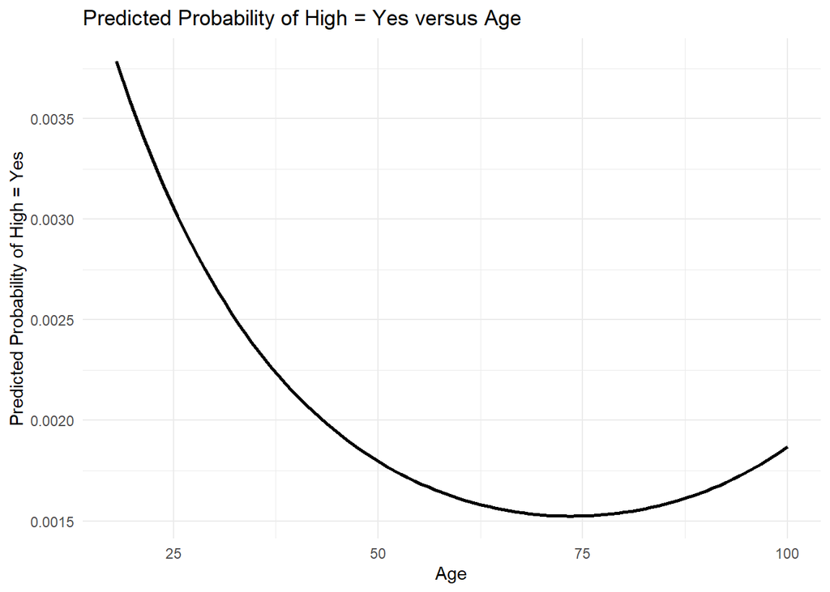

```r
plot_data_binomial <- data.frame(weight = 1000, distance = 10,
                                     age = age_values, carage = 5, sex = "male")

predicted_probs <- predict(logistic_model, newdata = plot_data_binomial, type="response")


plot_data_binomial$predicted_prob <- predict(logistic_model,
                                      newdata=plot_data_binomial, type="response")

ggplot(plot_data_binomial, aes(x = age, y = predicted_prob)) +
  geom_line(color = "black", size = 1) +
  labs(title = "Predicted Probability of High = Yes versus Age",
       x = "Age", y = "Predicted Probability of High = Yes") +
  theme_minimal()
```